# Statistical Models for Data Science Assignment 1: U.S. population nutrition survey

#### Visualize association between categorical variables

Chi-square tests and Cramer’s v to check significant and strong associations between categorical variables

```r
non_diet_vars <- c("region", "urb", "sex", "race", "self_rep_weight", "exercise")
# function to analyze and visualize categorical associations
# contingency tables have df > 3, so 0.15 represents a medium  effect size in cramers v
# I decided not to include the diet vars because of the low df and because the variables are highly imbalanced
analyze_cat_association <- function(var1, var2, data,
                                  p_threshold = 0.001,
                                  v_threshold = 0.15) {
    # contingency table
    cont_table <- table(data[[var1]], data[[var2]])

    # perform chi-square test
    chi_test <- chisq.test(cont_table)

    # calculate cramers v
    n <- sum(cont_table)
    min_dim <- min(nrow(cont_table), ncol(cont_table)) - 1
    cramers_v <- sqrt(chi_test$statistic / (n * min_dim))

    # check both significance and effect size
    if(chi_test$p.value < p_threshold && cramers_v > v_threshold) {

        df_plot <- as.data.frame(cont_table)
        names(df_plot) <- c("Var1", "Var2", "Freq")

        df_plot <- df_plot %>%
            group_by(Var1) %>%
            mutate(Prop = Freq/sum(Freq))

        p <- ggplot(df_plot, aes(x = Var1, y = Prop, fill = Var2)) +
            geom_bar(stat = "identity", position = "fill") +
            labs(title = paste(var1, "vs", var2),
                 subtitle = sprintf("p-value: %.3e, Cramer's V: %.3f",
                                  chi_test$p.value, cramers_v),
                 x = var1,
                 y = "Proportion") +
            theme_minimal() +
            theme(axis.text.x = element_text(angle = 45, hjust = 1))

        return(list(
            plot = p,
            p_value = chi_test$p.value,
            cramers_v = cramers_v,
            significant = TRUE
        ))
    } else {
        return(list(
            significant = FALSE,
            p_value = chi_test$p.value,
            cramers_v = cramers_v
        ))
    }
}

cat("Significant and Strong Associations between Categorical Variables:\n")
```

```
## Significant and Strong Associations between Categorical Variables:
```

```
##
## region vs urb:
## p-value: 8.567e-38
## Cramer's V: 0.152
```

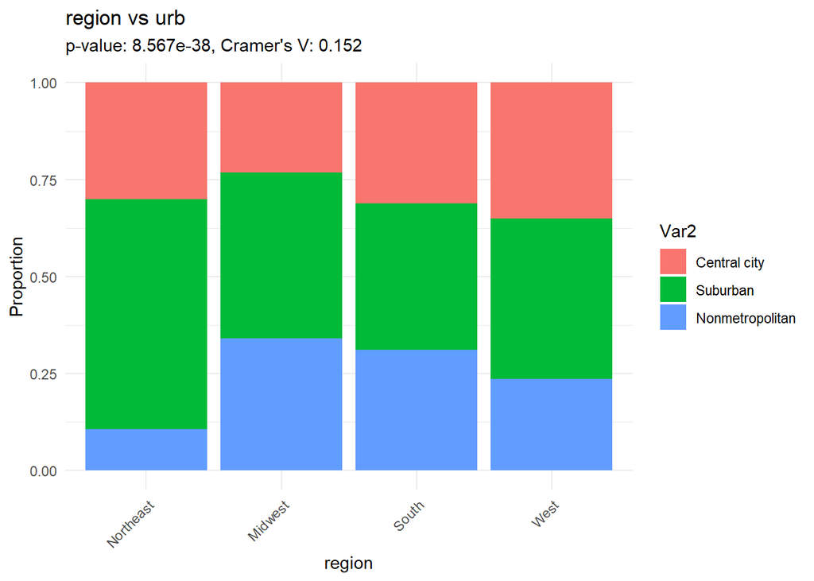

```
##
## region vs race:
## p-value: 1.077e-73
## Cramer's V: 0.177
```

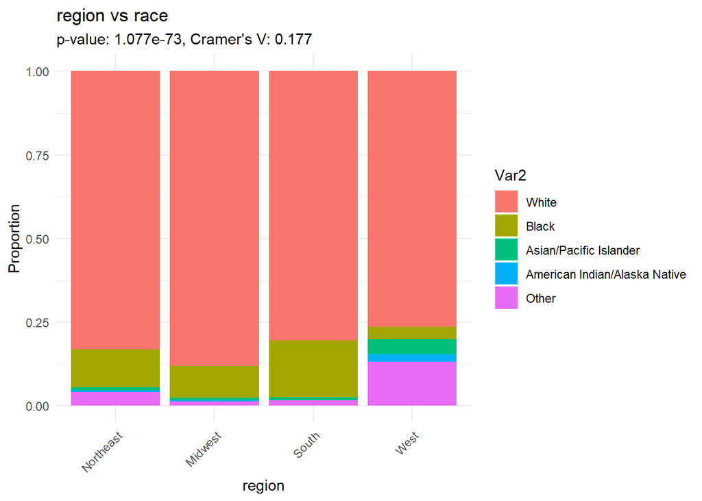

```
##
## urb vs race:
## p-value: 2.784e-67
## Cramer's V: 0.203
```

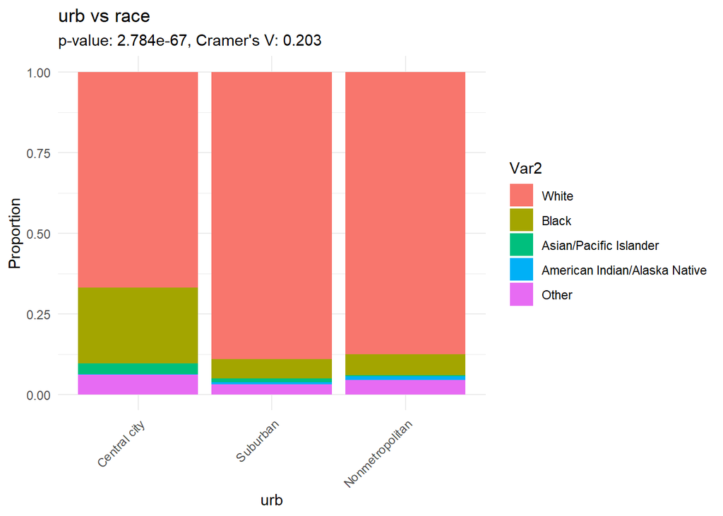

```
##
## sex vs self_rep_weight:
## p-value: 2.156e-20
## Cramer's V: 0.150
```

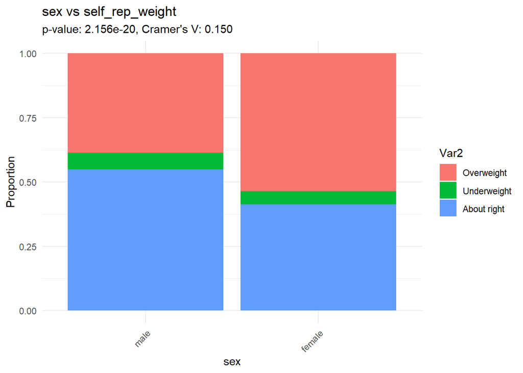

```
##
## sex vs exercise:
## p-value: 1.542e-24
## Cramer's V: 0.174
```

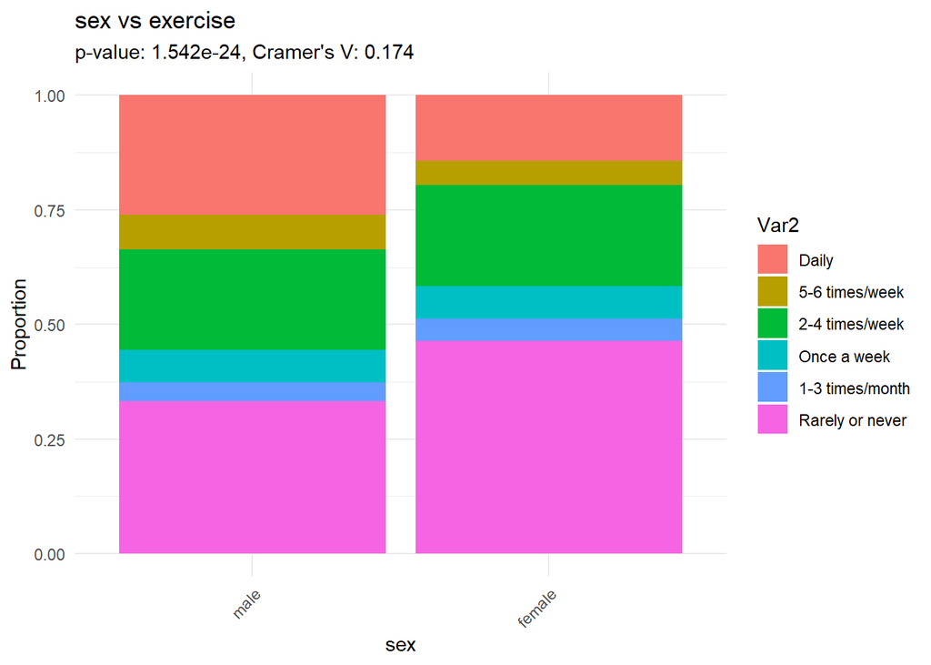

```r
for(i in 1:(length(non_diet_vars)-1)) {
    for(j in (i+1):length(non_diet_vars)) {
        var1 <- non_diet_vars[i]
        var2 <- non_diet_vars[j]

        result <- analyze_cat_association(var1, var2, df_nutrition)

        if(result$significant) {
            # Print results and plot
            cat(sprintf("\n%s vs %s:\n", var1, var2))
            cat(sprintf("p-value: %.3e\n", result$p_value))
            cat(sprintf("Cramer's V: %.3f\n\n", result$cramers_v))
            print(result$plot)
            ggsave(paste0("Plots/cat_cat",var1, "by", var2,".png"),
                   result$plot, width = 10, height = 5, dpi = 300)
        }
    }
}
```

## Task 4 - BMI Distribution and Transformation

Check the distribution of the response variable and whether there is a need for a transformation.

```r
# initial examination of BMI values
cat("Summary statistics of raw BMI:")
```

```
## Summary statistics of raw BMI:
```

```r
# detailed descriptive statistics
init_bmi_stats <- analyze_numeric_variables(df_nutrition, variables = "bmi_sp")
print(init_bmi_stats)
```

```
##   Variable n_obs n_valid     mean       sd median   min   max    q1    q3
## 1   bmi_sp  4036    4036 28.10417 11.80834 25.825 15.19 99.99 22.96 29.53
##        iqr skewness kurtosis n_outliers pct_outliers
## 1 6.570002 4.787362 29.16535        183     4.534192
```

```r
# data cleaning steps
n_total <- nrow(df_nutrition)
n_missing_initial <- sum(is.na(df_nutrition$bmi_sp))
n_extreme <- sum(df_nutrition$bmi_sp >= 99, na.rm=TRUE)

cat("\nData cleaning summary:")
```

```
##
## Data cleaning summary:
```

```r
cat("\n- Total observations:", n_total)
```

```
##
## - Total observations: 4036
```

```r
cat("\n- Initially missing:", n_missing_initial)
```

```
##
## - Initially missing: 0
```

```r
cat("\n- Extreme values (BMI ≥ 99):", n_extreme)
```

```
##
## - Extreme values (BMI ≥ 99): 85
```

```r
# clean BMI data
df_nutrition$bmi_sp[df_nutrition$bmi_sp >= 99] <- NA
n_missing_final <- sum(is.na(df_nutrition$bmi_sp))
cat("\n- Final missing count:", n_missing_final)
```

```
##
## - Final missing count: 85
```

```r
cat("\nSummary statistics of BMI after extreme values:")
```

```
##
## Summary statistics of BMI after extreme values:
```

```r
clean_bmi_stats <- analyze_numeric_variables(df_nutrition, variables = "bmi_sp")
print(clean_bmi_stats)
```

```
##   Variable n_obs n_valid     mean       sd median   min   max    q1    q3
## 1   bmi_sp  4036    3951 26.55765 5.370686  25.77 15.19 64.37 22.87 29.18
##        iqr skewness kurtosis n_outliers pct_outliers
## 1 6.309999 1.258051 6.321438        202      5.11263
```

Delete rows with missing response variable

```r
df_nutrition_clean <- df_nutrition %>%
  filter(!is.na(bmi_sp))
```

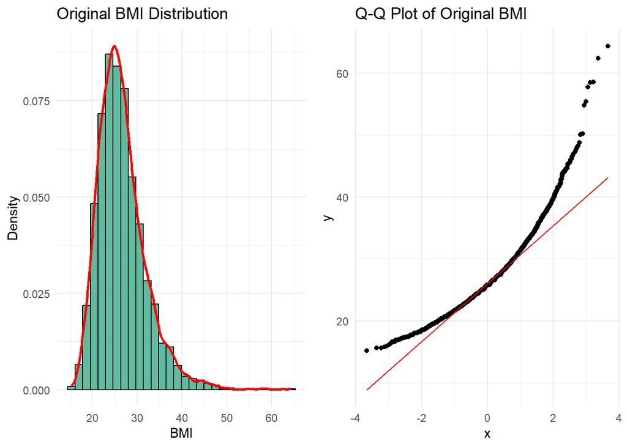

```r
# print distribution
p1 <- ggplot(df_nutrition_clean, aes(x = bmi_sp)) +
  geom_histogram(aes(y=..density..), fill = "#1B9E77", color = "black", alpha = 0.7, bins=30) +
  geom_density(color = "red", size = 1) +
  labs(title = "Original BMI Distribution",
       x = "BMI", y = "Density") +
  theme_minimal()

# QQ plot
p2 <- ggplot(df_nutrition_clean, aes(sample = bmi_sp)) +
  stat_qq() + stat_qq_line(color = "red") +
  labs(title = "Q-Q Plot of Original BMI") +
  theme_minimal()

grid.arrange(p1, p2, ncol=2)
```

```r
# calculate and store distribution metrics
dist_metrics <- data.frame(
  Metric = c("Skewness", "Kurtosis", "Shapiro-Wilk p-value"),
  Original = c(
    round(skewness(df_nutrition_clean$bmi_sp, na.rm=TRUE), digits = 2),
    round(kurtosis(df_nutrition_clean$bmi_sp, na.rm=TRUE), digits = 2),
    round(shapiro.test(df_nutrition_clean$bmi_sp)$p.value, digits = 5)
  )
)
print(dist_metrics)
```

```
##                 Metric Original
## 1             Skewness     1.26
## 2             Kurtosis     6.32
## 3 Shapiro-Wilk p-value     0.00
```

The response variable is highly non-normal: Skewness (1.26):  
A positive skew suggests a long tail on the right side of the distribution.  
A skewness value far from 0 indicates significant asymmetry.